# m1-autograded

## Module 1 - Autograded

### Outline:

**Here are the objectives of this assignment:**

1. Define and interpret the ANCOVA model with interaction terms.
2. Conduct basic hypothesis tests (full F-test, individual t-tests) to check whether there are statistically significant differences with respect to the mean of a continuous variable across groups.
3. Show that the one-way ANOVA (and ANCOVA) model(s) can be written as a linear regression model.
4. Define the one-way (single-factor) ANOVA model, and write the model in two different but equivalent ways: as a means model and effects model.
5. To apply your understanding of these models to a real-world datasets

**Here are some general tips:**

1. Read the questions carefully to understand what is being asked.
2. When you feel that your work is completed, feel free to hit the `Validate` button to see your results on the *visible* unit tests. If you have questions about unit testing, please refer to the "Module 0: Introduction" notebook provided as an optional resource for this course. In this assignment, there are hidden unit tests that check your code. **Do not misinterpret the feedback from visible unit tests as all possible tests for a given question--write your code carefully!**
3. Before submitting, we recommend restarting the kernel and running all the cells in order that they appear to make sure that there are no additional bugs in your code.

```r
# Run this cell to import the required packages for this assignment:
library(testthat)
library(tidyverse)
# remotes::install_github("allisonhorst/palmerpenguins")
# citation("palmerpenguins")
# library(palmerpenguins)
```

### Problem #1: Introduction to ANCOVA (20 points)

First, we import the `sightsing` dataset for you.

It contains two treatment groups. The main part of this question you are asked to fill in a function, `my_ancova_model` that returns the linear ANCOVA model from this dataset.

```r
### Read in the data and display means for each group.
sing = read.table('sightsing.dat', sep = ',')
names(sing) = c("treat", "test1", "test2")
sing = sing %>%
    mutate(treat = as.factor(treat))
print(head(sing,nrow(sing)))
sing %>%
    group_by(treat) %>%
    summarise(n_pre = n(), mean_test1 = mean(test1), n_post = n(), mean_test2 = mean(test2))
```

```
   treat test1 test2
1      1   0.0   8.5
2      1   0.0   0.0
3      1   0.0   4.3
4      1   2.5   0.0
5      1   0.0  25.6
6      1  10.7   0.0
7      1  46.9  63.9
8      1   0.0   0.0
9      1   6.4   4.3
10     1  27.7  23.4
11     1  21.3  36.2
12     1   0.0   0.0
13     1   0.0   4.3
14     1   0.0  17.0
```

[output cut: 26 more lines]

A tibble: 2 × 5

| treat <fct> | n_pre <int> | mean_test1 <dbl> | n_post <int> | mean_test2 <dbl> |
| --- | --- | --- | --- | --- |
| 1 | 20 | 7.710 | 20 | 11.935 |
| 2 | 20 | 8.215 | 20 | 22.295 |

#### 1. (a) Plot this data

Plot the `sing` data with `test1` on the x-axis and `test2` on the y-axis, with an attribute like color for the `treat` variable. This ggplot object will be stored in a variable denoted `p`. If you need a refresher on ggplot, check this link: https://ggplot2.tidyverse.org/

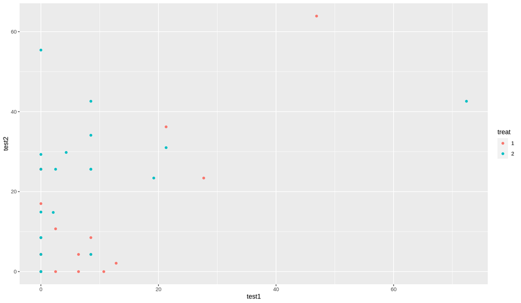

```r
options(repr.plot.width = 12, repr.plot.height = 7)
p = sing %>%
        ggplot(aes(x = test1, y = test2, color = treat)) +
        geom_point()

# your code here

print(p)
```

```r
# Test Cell
# Note: There may be hidden tests for each question!
# Make sure you are confident in your solutions.
```

#### 1. (b) Fill in the following function, which takes the dataset as an argument and returns the linear model object:

This model should be of the following structure:

$$Y_i = \beta_0 + \beta_1 X + \beta_2 Z + \varepsilon_i$$

Where:

- $Y_i$ is `test2`
- $X_i$ is `test1`
- $Z$ is an indicator for the `treat` group
- $\varepsilon_i \overset{iid}{\sim} N(0,\sigma^2)$

(tip: be sure to include a `return` statement)

(note: the order you input the variables into your lm() function will impact grading. Use the same order as the equation above)

```r
summary(lm(test2 ~ test1 + treat, data = sing))
```

```
Call:
lm(formula = test2 ~ test1 + treat, data = sing)

Residuals:
    Min      1Q  Median      3Q     Max
-18.164  -8.876  -3.077   8.527  37.962

Coefficients:
            Estimate Std. Error t value Pr(>|t|)
(Intercept)   7.3766     3.2295   2.284 0.028199 *
test1         0.5912     0.1519   3.893 0.000399 ***
treat2       10.0614     4.2571   2.363 0.023470 *
---
Signif. codes:  0 ‘***’ 0.001 ‘**’ 0.01 ‘*’ 0.05 ‘.’ 0.1 ‘ ’ 1

Residual standard error: 13.46 on 37 degrees of freedom
Multiple R-squared:  0.3629,	Adjusted R-squared:  0.3285
F-statistic: 10.54 on 2 and 37 DF,  p-value: 0.0002385
```

```r
my_ancova_model <- function(mydataset){
    # your code here
    my_lm <- lm(test2 ~ test1 + treat, data = mydataset)
    return(my_lm)
}
```

```r
# Test Cell
if(class(my_ancova_model(sing)) == 'lm'){
    expect_is(my_ancova_model(sing), "lm")
    print('Checking linear model object: ... Correct')
    print('Tip: Make sure that your linear model object has the correct variables!')
}else{
    print('Checking linear model object: ... Incorrect')
    print('Tip: check out the lm() function!')
}

# This cell has hidden test cases that will run after submission.
```

```
[1] "Checking linear model object: ... Correct"
[1] "Tip: Make sure that your linear model object has the correct variables!"
```

#### 1. (c) Fill in the following function which takes a linear model as an argument and returns the p-values column from the `anova` table:

```r
my_ancova_table <- function(myancovamodel){
    # your code here
    my_pvals <- anova(myancovamodel)$`Pr(>F)`[!is.na(anova(myancovamodel)$`Pr(>F)`)]
    return(my_pvals)
}
```

```r
# Test Cell
if(test_that('Checking p-values type',{expect_is(my_ancova_table(my_ancova_model(sing)),'numeric')})){
    print('Checking p-values type: Correct')
}
# This cell has hidden test cases that will run after submission.
```

```
[1] "Checking p-values type: Correct"
```

### Problem #2. Penguins dataset analysis (15 points)

First, we import the `penguins` dataset and plot it for you. More info on this dataset can be found here:

Gorman KB, Williams TD, Fraser WR (2014) Ecological Sexual Dimorphism and Environmental Variability within a Community of Antarctic Penguins (Genus Pygoscelis). PLoS ONE 9(3): e90081. https://doi.org/10.1371/journal.pone.0090081

https://github.com/allisonhorst/palmerpenguins

In this question, we will explore linear ANCOVA models and potential interactions.

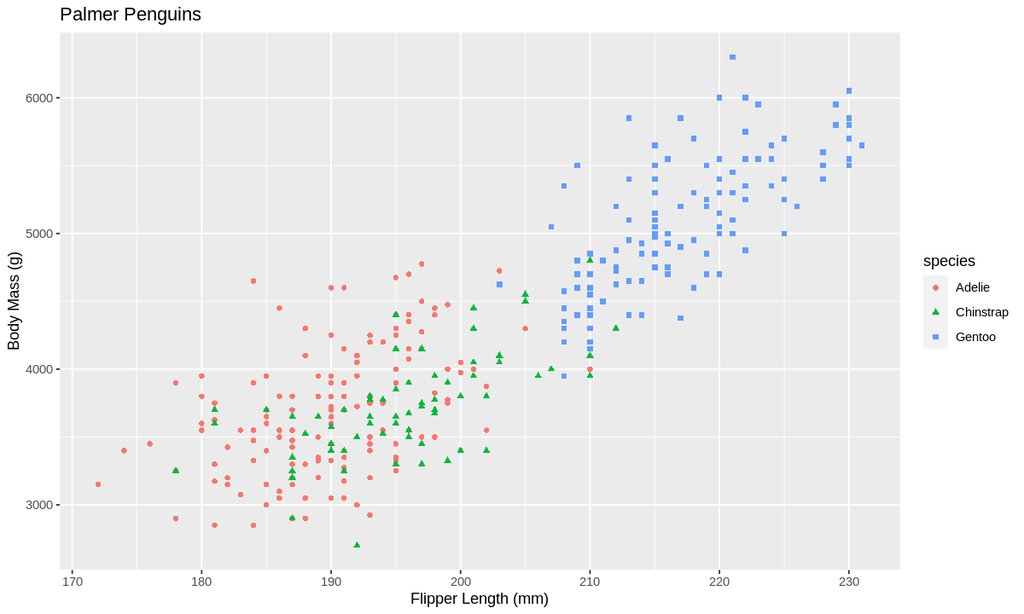

```r
penguins <- read.table('penguins.csv', sep = ',')
penguins <- penguins %>% drop_na()
options(repr.plot.width=10, repr.plot.height=6)
p = ggplot(data = penguins) +
        geom_point(aes(x = flipper_length_mm, y = body_mass_g,shape = species,color=species)) +
        xlab('Flipper Length (mm)') + ylab('Body Mass (g)') +
        ggtitle('Palmer Penguins')
p
```

#### 2. (a) Create two models regressing body mass on flipper length and including species (as a factor):

- one model in a variable `penguins_no_interaction` without interaction between flipper length and species
  - (hint: of the form $Y_i = \beta_0 + \beta_1 X + \beta_2 Z + \varepsilon_i$)
- one model in a variable `penguins_with_interaction` with interaction between flipper length and species
  - (hint: of the form $Y_i = \beta_0 + \beta_1 X + \beta_2 Z + \beta_3XZ + \varepsilon_i$)

(tip: use `head(penguins)` to take a look at the dataset and remember to input your variables in the same order as the models above)

```r
penguins_no_interaction = lm(body_mass_g ~ flipper_length_mm + species, data = penguins)

penguins_with_interaction = lm(body_mass_g ~ flipper_length_mm + species + flipper_length_mm:species, data = penguins)

# your code here

penguins_no_interaction ; penguins_with_interaction
```

```
Call:
lm(formula = body_mass_g ~ flipper_length_mm + species, data = penguins)

Coefficients:
      (Intercept)  flipper_length_mm   speciesChinstrap      speciesGentoo
         -4013.18              40.61            -205.38             284.52
```

```
Call:
lm(formula = body_mass_g ~ flipper_length_mm + species + flipper_length_mm:species,
    data = penguins)

Coefficients:
                       (Intercept)                   flipper_length_mm
                         -2508.088                              32.689
                  speciesChinstrap                       speciesGentoo
                          -529.108                           -4166.117
flipper_length_mm:speciesChinstrap     flipper_length_mm:speciesGentoo
                             1.884                              21.477
```

```r
# Test Cell
if(test_that('Checking no_interaction linear model object TYPE:',{expect_is(penguins_no_interaction,'lm')})){
    print('Checking no_interaction linear model object TYPE: ... Correct')
}
# This cell has hidden test cases that will run after submission.
```

```
[1] "Checking no_interaction linear model object TYPE: ... Correct"
```

```r
# Test Cell
if(test_that('Checking with_interaction linear model object TYPE',{expect_is(penguins_with_interaction,'lm')})){
    print('Checking with_interaction linear model object TYPE: ... Correct')
}
# This cell has hidden test cases that will run after submission.
```

```
[1] "Checking with_interaction linear model object TYPE: ... Correct"
```

#### 2. (b) Fill in the following function to compute the Mean Square Error (MSE) from a linear model object:

```r
extract_mse <- function(linear_model){
    # your code here
    return(mean(resid(linear_model)^2))
}
```

```r
# Test Cell
if(test_that('Checking mse_type',{expect_is(extract_mse(lm(body_mass_g ~ flipper_length_mm, data = penguins)),'numeric')})){
    print('Checking mse_type: ... Correct')
}

# This cell has hidden test cases that will run after submission.
```

```
[1] "Checking mse_type: ... Correct"
```